# Spatial neighborhood analysis

Data Lab for ALSF

2026

## Objectives

- Use `hoodscanR` to create a neighborhood profile for each cell
- Use the output from `hoodscanR` to quantify the complexity of spatial neighborhoods
- Identify cell types that are commonly co-localized
- Use `hoodscanR` for domain detection

## Introduction

Spatial neighborhood analysis is a way to summarize which cell types are near other cell types and describe the local tissue environment.

In this notebook we’ll use the [`hoodscanR`](https://www.bioconductor.org/packages/release/bioc/html/hoodscanR.html) package to look at the following characteristics:

1. Neighborhood profiles, or the mix of cell types among each cells’ nearest neighbors.
2. Neighborhood complexity, which defines if a cell is sitting in a “pure” environment dominated by one cell type, or a highly mixed one.
3. Co-localization, which tells us which cell types tend to show up in the same neighborhoods across the whole slide.
4. Domain detection, which uses clustering of neighborhood profiles to identify spatial domains that share a similar neighborhood profile.

The general idea behind `hoodscanR` is to look at each cell’s k-nearest neighbors, convert the distances to those neighbors into probabilities, and then summarize those probabilities by cell type. The result is one profile per cell. Each profile contains the probability that another cell in the given cell’s neighborhood is a particular cell type, for each cell type present in the data.

## Set up

To begin, we’ll load the packages we’ll use throughout this notebook and set the random seed. Setting a seed matters here because a few of the calculations in `hoodscanR` involve randomness, and we want the notebook to give the same results each time it is run.

```r
suppressPackageStartupMessages({
  # The main class we use for spatial transcriptomic data
  library(SpatialExperiment)
  # functions for plotting
  library(ggplot2)
})
# Set theme for ggplot2 plotting
theme_set(theme_bw())

# Set a seed so the random steps (tau estimation, k-means) are reproducible
set.seed(2026)
```

### Directories and files

Next, we’ll define paths to the normalized SPE object that we prepared in the previous notebook. This object is stored in `data/brca-xenium/normalized`.

```r
# top level data directory for brca xenium data
data_dir <- file.path("data", "brca-xenium")

# data directory for the normalized data
normalized_dir <- file.path(data_dir, "normalized")

# the normalized SPE object we will read in
normalized_rds <- file.path(normalized_dir, "brca_xenium_normalized.rds")

# the path to a tsv file containing a palette of colors
# for the cell types present in this dataset
cell_type_palette_file <- file.path(
  data_dir,
  "brca_xenium_cell_type_palette.tsv"
)
```

We’ll also set up the output paths we need at the end of the notebook.

```r
# path to results directory
results_dir <- file.path("results", "brca-xenium")
fs::dir_create(results_dir)

# path to output spe file
hoodscanr_results_file <- file.path(results_dir, "hoodscanr_spe.rds")
```

Now we’ll read in the normalized object.

```r
# read the normalized SpatialExperiment object created in the previous notebook
spe <- readr::read_rds(normalized_rds)
```

As a reminder, let’s look at the cell types that are present in this dataset. We’ll use the `cell_types_lumped` column that we created in the previous notebook for the plot and for the neighborhood analysis. For the color palette, we’ll read in a TSV file that we have prepared with the colors to use for each cell type. In general, saving color palettes as a TSV files can be a helpful way to use the same color palettes across multiple notebooks and/or scripts.

```r
# read in a custom palette mapping each cell type to a fixed color, so that
# colors stay consistent across every plot in the notebook
cell_type_palette <- readr::read_tsv(
  cell_type_palette_file,
  col_types = list(.default = "c")
) |>
  # turn the dataframe into a named list
  # where the first column is names and the second column is values
  tibble::deframe()

cell_type_palette
```

```
           Stromal              Tumor               DCIS         Macrophage
         "#F6222E"          "#3283FE"          "#325A9B"          "#85660D"
Myoepithelial cell        Endothelial       CD4+ T Cells       CD8+ T Cells
         "#F7E1A0"          "#AA0DFE"          "#16FF32"          "#1C8356"
           B Cells  Perivascular-Like     Dendritic cell         Mast Cells
         "#FC1CBF"          "#FEAF16"          "#1CBE4F"          "#565656"
            Hybrid          Unlabeled
         "#FFFF00"           "grey90"
```

[output not shown]

Setting the cell type column as a factor lets us control the order the cell types appear in legends and plots. Rather than R defaulting to using alphabetical order, we want to specify that the palette order should match the order in the TSV file.

```r
# re-order celltypes for plotting by setting them as a factor,
# using the palette order as the factor level order
spe$cell_types_lumped <- factor(
  spe$cell_types_lumped,
  levels = names(cell_type_palette)
)
```

With the palette and factor levels in place, we can plot the cells in their spatial coordinates, colored by cell type.

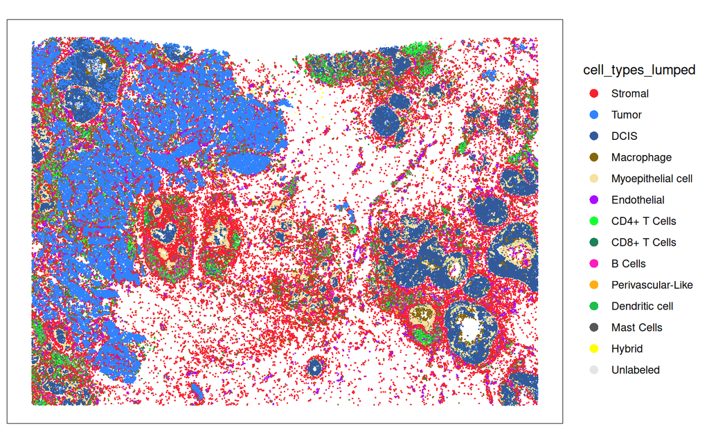

```r
# plot the cells at their spatial coordinates, colored by lumped cell type
ggspavis::plotCoords(spe, annotate = "cell_types_lumped") +
  scale_color_manual(values = cell_type_palette)
```

Note that we still have a fair number of “Unlabeled” cells. According to the original publication, the Xenium data was projected onto the single-cell RNA-seq data, and the 30 nearest neighbors were identified for each cell. If at least half of those single-cell neighbors shared the same cell type, then that cell type was used as the cell type label for the Xenium cell. If this criterion was not met, then the cell was annotated as “Unlabeled”.

Because all “Unlabeled” cells share this label, they would be grouped together in the neighborhood analysis. Most likely, these cells are not all the same cell type, so let’s remove them to ensure they don’t confound our results.

```r
# remove any unlabeled cells from the spe
spe <- spe[, spe$cell_types_lumped != "Unlabeled"]
```

## Identifying cell neighborhoods with `hoodscanR`

The core output of `hoodscanR` is a neighborhood profile for every cell. To build it, the package takes three steps that we’ll walk through one at a time:

1. Find the k nearest neighboring cells for each cell (`findNearCells()`).
2. Convert the distances to those neighbors into probabilities, so that closer cells contribute more (`scanHoods()`).
3. Group those per-neighbor probabilities by cell type, giving each cell a probability of being surrounded by each cell type (`mergeByGroup()`).

The end result is a matrix with one row per cell and one column per cell type, where each value is the probability that the a cell in the local neighborhood is that cell type.

### Setup the `hoodscanR` object

`hoodscanR` expects the annotation it should use to live in a standardized `colData` column called `cell_annotation`, and it expects the spatial coordinates to be in the `spatialCoords` of the object. Let’s first add a new column to the `colData` named `cell_annotation` and fill it with the same contents as `cell_types_lumped`.

```r
# reformat the SPE for hoodscanR
# which expects a column named `cell_annotation` to use for neighborhood identification
spe$cell_annotation <- spe$cell_types_lumped
```

Now let’s check to see if the spatial coordinates are indeed present in `spatialCoords`.

```r
spatialCoords(spe)[1:10, ]
```

```
   x_centroid y_centroid
2    826.3420   328.0318
4    824.2284   334.2526
5    841.3575   332.2425
8    828.7262   341.7123
9    847.6031   344.5115
10   838.7647   345.3068
11   839.6843   351.1779
14   848.8834   366.0542
15   832.4334   363.2038
16   822.4167   371.7484
```

Great, it looks like our object is all set to run `hoodscanR`.

### Generate the probability matrix

The first step is to find the nearest neighbors for each cell based on physical distance. `findNearCells()` does this using an approximate nearest-neighbor search, returning the `k` closest cells for every cell in the dataset. Note that distance here is the Euclidean distance between cells on the slide.

The choice of the number of neighbors, `k`, sets the size of the neighborhood we’re describing. A small `k` will use only the tight ring of cells immediately around each cell, while a large `k` describes a broader region of tissue.

Here we’ll use `k = 100`, which is the default for `findNearCells()`. 100 neighbors is large enough that each cell’s profile is stable, meaning one unusual neighbor can’t dominate it, but still small enough to describe a local region rather than the whole slide.

When you apply this to your own data, it’s worth trying multiple values of `k`. This can tell you about stability of the neighborhoods and how changing the size of the neighborhood might impact your overall results. For example, choosing to include only 10 cells in each cell’s neighborhood is likely to give you more homogeneous neighborhood profiles than choosing 100 cells simply because there are fewer cells to choose from.

```r
# for each cell, find its k nearest neighboring cells
neighbors <- hoodscanR::findNearCells(
  spe,
  k = 100, # number of nearest neighbors to consider for each cell
  anno_col = "cell_annotation" # default
)
```

What’s inside this object? It’s a list with two elements, `cells` and `distance`. Both have the same shape, one row per cell and one column per neighbor, but `cells` is a data frame holding cell type labels and `distance` is a numeric matrix.

```r
str(neighbors, max.level = 1)
```

```
List of 2
 $ cells   :'data.frame':   135944 obs. of  100 variables:
 $ distance: num [1:135944, 1:100] 6.57 6.57 11.97 8.71 8.87 ...
  ..- attr(*, "dimnames")=List of 2
```

The `cells` data frame has one row per cell and one column per neighbor (`nearest_cell_1` through `nearest_cell_100`). Each entry is the cell type of that neighbor.

```r
neighbors$cells[1:10, 1:10]
```

|  | nearest_cell_1 | nearest_cell_2 | nearest_cell_3 | nearest_cell_4 | nearest_cell_5 | nearest_cell_6 | nearest_cell_7 | nearest_cell_8 | nearest_cell_9 | nearest_cell_10 |
| --- | --- | --- | --- | --- | --- | --- | --- | --- | --- | --- |
| 2 | Tumor | DCIS | DCIS | DCIS | DCIS | DCIS | DCIS | Tumor | DCIS | DCIS |
| 4 | DCIS | DCIS | DCIS | Tumor | DCIS | DCIS | Tumor | DCIS | DCIS | Macrophage |
| 5 | DCIS | DCIS | Macrophage | Macrophage | DCIS | DCIS | Tumor | DCIS | Tumor | DCIS |
| 8 | Tumor | Tumor | Macrophage | Tumor | DCIS | DCIS | Macrophage | DCIS | DCIS | Macrophage |
| 9 | Macrophage | Macrophage | DCIS | Tumor | DCIS | DCIS | DCIS | Tumor | DCIS | Tumor |
| 10 | Macrophage | Macrophage | DCIS | DCIS | Tumor | Tumor | DCIS | Tumor | DCIS | DCIS |
| 11 | Macrophage | Macrophage | DCIS | DCIS | Tumor | DCIS | DCIS | Tumor | DCIS | DCIS |
| 14 | Tumor | Tumor | Tumor | Tumor | Tumor | DCIS | DCIS | Macrophage | DCIS | DCIS |
| 15 | DCIS | Macrophage | Macrophage | Tumor | Tumor | DCIS | Tumor | Tumor | Macrophage | DCIS |
| 16 | Tumor | DCIS | DCIS | Tumor | DCIS | Macrophage | DCIS | Tumor | Tumor | DCIS |

The `distance` matrix has the same shape, but each entry is the physical distance from the cell to that neighbor.

```r
neighbors$distance[1:10, 1:5]
```

```
   nearest_cell_1 nearest_cell_2 nearest_cell_3 nearest_cell_4 nearest_cell_5
2        6.570066      12.315512      13.300914       13.81841       13.88673
4        6.570066       7.442557       8.710779       10.30056       15.38705
5       11.969295      12.999877      13.319093       13.76716       15.59475
8        8.710779       9.978655      10.662621       10.84571       13.00335
9        8.874072      10.351267      13.767158       14.40574       15.54274
10       5.942635       8.874072      10.662621       13.31909       15.97432
11       5.942635      10.351267      14.042763       14.48013       15.65110
14       9.098504      10.616884      12.345086       13.51295       16.43499
15       7.852321      13.166001      14.042763       14.41135       15.88939
16       7.748430      10.653404      13.166001       13.20315       14.66046
```

Two things are worth noticing about the row and column names here.

1. The row names are the cell IDs carried over from the SPE object. Because we filtered out low-quality cells in the previous notebook and removed the “Unlabeled” cells, some IDs may be missing. The jumps in ID numbers are expected.
2. The column names are ranks, not cell IDs. `nearest_cell_1` is each cell’s closest neighbor, `nearest_cell_2` is its second closest, and so on out to the 100th. This is why the distances increase from left to right in every row.

Next we convert those distances into probabilities with `scanHoods()`. For each cell, the distances to its neighbors are passed through a softmax transformation, which transforms a vector into a probability distribution where all values sum to 1. The effect is that nearer cells get more weight than farther ones.

The softmax works in two steps.

- First, each neighbor’s distance is turned into a weight that shrinks exponentially as the distance grows, so a cell twice as far away contributes much less than half as much.
- Second, all 100 weights for a cell are divided by their sum, so they add up to 1 and can be read as probabilities. The result is that the closest neighbors take up most of the probability and distant neighbors contribute very little.

The `tau` parameter controls how quickly that weight falls off with distance.

- A small `tau` makes the drop-off sharp, so the profile is dominated by the closest handful of cells, giving a very local view.
- A large `tau` makes the drop-off gradual, so all 100 neighbors contribute more evenly, giving a more global view.

Note that the choice of `k` will dictate how many neighbors are included in these calculations, so both `k` and `tau` work together to generate the final neighborhood profile. It’s important to choose both of these parameters based on your scientific question.

We’ll use the default value of `tau`, which is the median of the squared distances divided by 5. This is recommended by the authors to capture local neighborhoods. `scanHoods()` reports the value it used, so you’ll see it printed below.

```r
# convert neighbor distances into probabilities
prob_mtx <- hoodscanR::scanHoods(neighbors$distance)
```

```
Tau is set to: 555.653294752244
```

In this matrix each row is a cell and each column is one of its 100 neighbors. The value is the probability weight assigned to that neighbor and every row sums to 1.

```r
prob_mtx[1:10, 1:10]
```

```
   nearest_cell_1 nearest_cell_2 nearest_cell_3 nearest_cell_4 nearest_cell_5
2      0.06707938     0.05517997     0.05272932     0.05141420     0.05123938
4      0.06319465     0.06181938     0.05958170     0.05642742     0.04460334
5      0.05979738     0.05709126     0.05623454     0.05501960     0.04995464
8      0.06066333     0.05813072     0.05667236     0.05627214     0.05129493
9      0.06361009     0.06044065     0.05211190     0.05045168     0.04745272
10     0.06882111     0.06364639     0.05976723     0.05329303     0.04633164
11     0.06853840     0.06022672     0.05121609     0.05007906     0.04699798
14     0.06027920     0.05711762     0.05318073     0.05036759     0.04302836
15     0.06459289     0.05283149     0.05061130     0.04966499     0.04581904
16     0.06209346     0.05639809     0.05063924     0.05055004     0.04698771
   nearest_cell_6 nearest_cell_7 nearest_cell_8 nearest_cell_9 nearest_cell_10
2      0.04740192     0.04680009     0.04370238     0.03878705      0.03620034
4      0.04126427     0.04000502     0.03998853     0.03807111      0.03747641
5      0.04941534     0.04530784     0.04500736     0.04336863      0.04131297
8      0.04914829     0.04768173     0.04440555     0.04192216      0.03610758
9      0.04723099     0.04147463     0.04084104     0.03805770      0.03728859
10     0.04024048     0.03833941     0.03554777     0.03302993      0.03246821
11     0.04211375     0.03811618     0.03549778     0.03318893      0.03199567
14     0.04260487     0.04236608     0.04034205     0.03803928      0.03767731
15     0.04370442     0.04366509     0.04105574     0.03773105      0.03066415
16     0.04436802     0.04036051     0.03846218     0.03421039      0.03412364
```

Right now the columns are individual neighbors, which isn’t very interpretable on its own. To get an object we can work with more easily, we’ll use the `mergeByGroup()` function which adds up the probability weights of all neighbors that share a cell type. It needs both the probability matrix (for the weights) and the `cells` matrix (for the cell type of each neighbor).

```r
# collapse the per-neighbor probabilities into one probability per cell type
hoods <- hoodscanR::mergeByGroup(
  prob_mtx,
  neighbors$cells
)
```

Now each row is still a cell, but the columns are cell types, and each value is the probability that another cell in the focal cell’s neighborhood is that cell type. These per-cell probabilities are the neighborhood profiles that we will explore for the rest of the notebook.

```r
hoods[1:10, ]
```

```
   B Cells CD4+ T Cells CD8+ T Cells      DCIS Dendritic cell Endothelial
2        0            0            0 0.7414135              0           0
4        0            0            0 0.7705026              0           0
5        0            0            0 0.6413519              0           0
8        0            0            0 0.6036559              0           0
9        0            0            0 0.5694475              0           0
10       0            0            0 0.5798231              0           0
11       0            0            0 0.5362634              0           0
   Hybrid Macrophage Mast Cells Myoepithelial cell Perivascular-Like
2       0 0.07459718          0       0.0001507990                 0
4       0 0.09217242          0       0.0002726326                 0
5       0 0.15425961          0       0.0000000000                 0
8       0 0.15676393          0       0.0003526234                 0
9       0 0.13128290          0       0.0001865554                 0
10      0 0.14788132          0       0.0001733349                 0
11      0 0.15371865          0       0.0005321674                 0
        Stromal     Tumor
2  0.0000000000 0.1838385
4  0.0000000000 0.1370523
5  0.0000000000 0.2043885
8  0.0000000000 0.2392276
9  0.0004477663 0.2986353
10 0.0001249546 0.2719973
11 0.0002895069 0.3091963
 [ reached 'max' / getOption("max.print") -- omitted 3 rows ]
```

A nice way to get a feel for these profiles is to plot them as a heatmap, with cells as rows and cell types as columns. We’ll use the `ComplexHeatmap` package to do this since it has some nice customization options, allowing us to have more control over the plot’s aesthetics. You can learn more about this package, including all of the many plot modifications, from the [`ComplexHeatmap` documentation](https://jokergoo.github.io/ComplexHeatmap-reference/book/). (`hoodscanR` also provides a function, `hoodscanR::plotTissue()`, to make a similar plot with fewer options for customization).

We will plot the first 500 cells here just to keep the heatmap legible. Each column will be a cell and each row will represent a cell type. The color indicates the probability of a given cell type appearing in the nearest 100 neighbors of each cell.

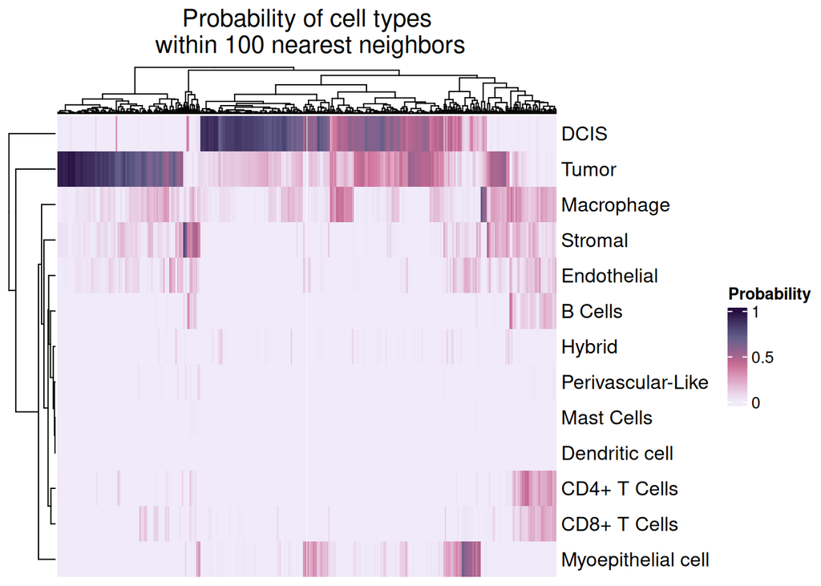

```r
# plot the neighborhood profiles for the first 500 cells
ComplexHeatmap::Heatmap(
  t(hoods[1:500, ]), # transpose so cells are columns
  col = scico::scico(200, palette = "acton", direction = -1),
  name = "Probability",
  column_title = "Probability of cell types\n within 100 nearest neighbors",
  column_title_gp = grid::gpar(fontsize = 15),
  column_dend_height = grid::unit(1, "cm"),
  row_dend_width = grid::unit(1, "cm"),
  cluster_rows = TRUE, # group cells with similar profiles together
  cluster_columns = TRUE, # group cell types that co-occur together
  show_column_names = FALSE # hide per-cell labels; there are too many to read
)
```

This heatmap helps us visualize neighborhood profiles and makes it easy to see when certain cell types might be found in the same neighborhood. For example, there appear to be immune cell neighborhoods where macrophages, T cells, and B cells are all found in the neighborhood of the same cell. We also see tumor neighborhoods with both DCIS and tumor cells. However, this heatmap only tells you about the neighborhoods of individual cells and does not provide information about how cell types as a whole interact together. To understand that, we will have to look at the neighborhood profiles of all cells together, which we will do in a later section.

Do you see any indication that some cells have neighborhoods comprised of both tumor and immune cells? Are there other patterns you notice?

## Measuring neighborhood complexity

A neighborhood profile can be dominated by a single cell type or a mix of many cell types. `hoodscanR` quantifies this using perplexity, which is the effective number of cell types in the neighborhood. A perplexity near 1 means the neighborhood is essentially one cell type and a higher perplexity means a more mixed environment.

Before we can calculate this metric, we need to attach the neighborhood profiles back onto our SPE object with `mergeHoodSpe()`, which adds one column per cell type to the `colData`.

```r
# merge the neighborhood profiles back into the spe object
spe <- hoodscanR::mergeHoodSpe(
  spe,
  hoods
)

# one column per cell type has been added
# with the probability of the cell type in the neighborhood of the row's cell
colData(spe) |>
  head()
```

```
DataFrame with 6 rows and 29 columns
    cell_id transcript_counts control_probe_counts control_codeword_counts
  <numeric>         <integer>            <integer>               <integer>
1         2                94                    0                       0
2         4                11                    0                       0
  total_counts cell_area nucleus_area   sample_id in_tissue
     <integer> <numeric>    <numeric> <character> <logical>
1           94  197.0167      42.1308    sample01      TRUE
2           11   42.3114      10.0698    sample01      TRUE
  cell_type_annotation cell_types_lumped counts_per_area_outliers
           <character>          <factor>                <logical>
1               DCIS_2        DCIS                          FALSE
2       Invasive_Tumor        Tumor                         FALSE
  control_exclude   exclude sizeFactor cell_annotation   B Cells CD4+ T Cells
        <logical> <logical>  <numeric>        <factor> <numeric>    <numeric>
1           FALSE     FALSE  0.5071258      DCIS               0            0
2           FALSE     FALSE  0.0593445      Tumor              0            0
  CD8+ T Cells      DCIS Dendritic cell Endothelial    Hybrid Macrophage
     <numeric> <numeric>      <numeric>   <numeric> <numeric>  <numeric>
1            0  0.741413              0           0         0  0.0745972
2            0  0.770503              0           0         0  0.0921724
  Mast Cells Myoepithelial cell Perivascular-Like     Stromal     Tumor
   <numeric>          <numeric>         <numeric>   <numeric> <numeric>
1          0        0.000150799                 0 0.000000000  0.183839
2          0        0.000272633                 0 0.000000000  0.137052
 [ reached 'max' / getOption("max.print") -- omitted 4 rows ]
```

Now we can calculate perplexity from those probability columns. Note that running the `calcMetrics()` function will also calculate entropy, which is ultimately used to calculate perplexity. We will focus on perplexity for these plots, but you could theoretically use either metric as the trends will be the same.

```r
# calculate entropy and perplexity from the neighborhood probability columns
spe <- hoodscanR::calcMetrics(
  spe,
  pm_cols = colnames(hoods)
)

# now we can see both entropy and perplexity added to the colData
colData(spe) |>
  head()
```

```
DataFrame with 6 rows and 31 columns
    cell_id transcript_counts control_probe_counts control_codeword_counts
  <numeric>         <integer>            <integer>               <integer>
1         2                94                    0                       0
2         4                11                    0                       0
  total_counts cell_area nucleus_area   sample_id in_tissue
     <integer> <numeric>    <numeric> <character> <logical>
1           94  197.0167      42.1308    sample01      TRUE
2           11   42.3114      10.0698    sample01      TRUE
  cell_type_annotation cell_types_lumped counts_per_area_outliers
           <character>          <factor>                <logical>
1               DCIS_2        DCIS                          FALSE
2       Invasive_Tumor        Tumor                         FALSE
  control_exclude   exclude sizeFactor cell_annotation   B Cells CD4+ T Cells
        <logical> <logical>  <numeric>        <factor> <numeric>    <numeric>
1           FALSE     FALSE  0.5071258      DCIS               0            0
2           FALSE     FALSE  0.0593445      Tumor              0            0
  CD8+ T Cells      DCIS Dendritic cell Endothelial    Hybrid Macrophage
     <numeric> <numeric>      <numeric>   <numeric> <numeric>  <numeric>
1            0  0.741413              0           0         0  0.0745972
2            0  0.770503              0           0         0  0.0921724
  Mast Cells Myoepithelial cell Perivascular-Like     Stromal     Tumor
   <numeric>          <numeric>         <numeric>   <numeric> <numeric>
1          0        0.000150799                 0 0.000000000  0.183839
2          0        0.000272633                 0 0.000000000  0.137052
    entropy perplexity
  <numeric>  <numeric>
1   1.05050    2.07125
2   1.00302    2.00419
 [ reached 'max' / getOption("max.print") -- omitted 4 rows ]
```

Since the perplexity values are now in the SPE object, we can use the `ggspavis::plotCoords()` function we have used previously. (`hoodscanR` also provides a function, `hoodscanR::plotTissue()`, to make these plots, but the output is the same).

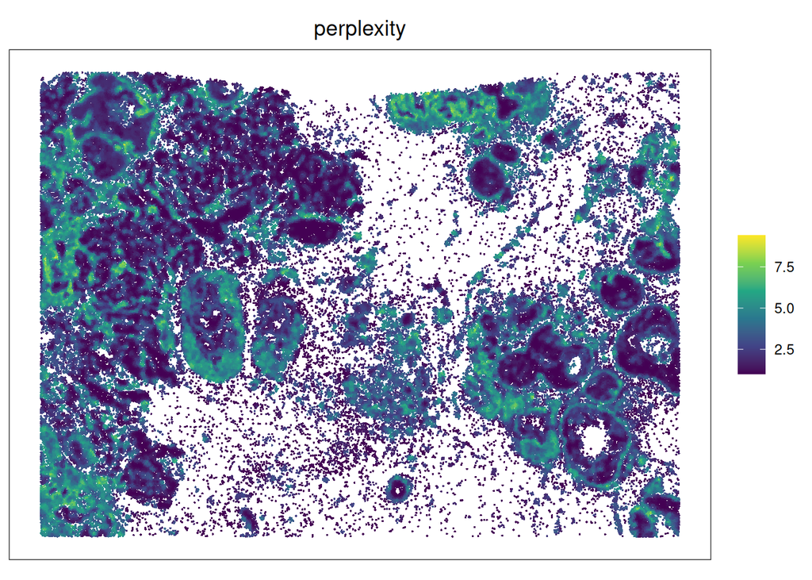

```r
# plot perplexity across the tissue to see where neighborhoods are more mixed
ggspavis::plotCoords(spe, annotate = "perplexity") +
  scale_color_viridis_c()
```

The perplexity measure helps classify regions of the slide as homogeneous or complex. Areas with high perplexity (yellow) are more complex, meaning multiple cell types are present in a single neighborhood. Areas with low perplexity (blue) are more homogeneous, meaning the neighborhood is dominated by a single cell type.

## Co-localization

We can also use the neighborhood profiles to look at which cell types tend to appear close to each other based on physical distance or are co-localized. `plotColocal()` answers this by first correlating the per-cell neighborhood probabilities across every pair of cell types and then plotting that correlation in a heatmap.

Cell types with a correlation close to 1 are more likely to be found close together on the slide. Cell types with a correlation close to -1 are more likely to be found far from each other on the slide.

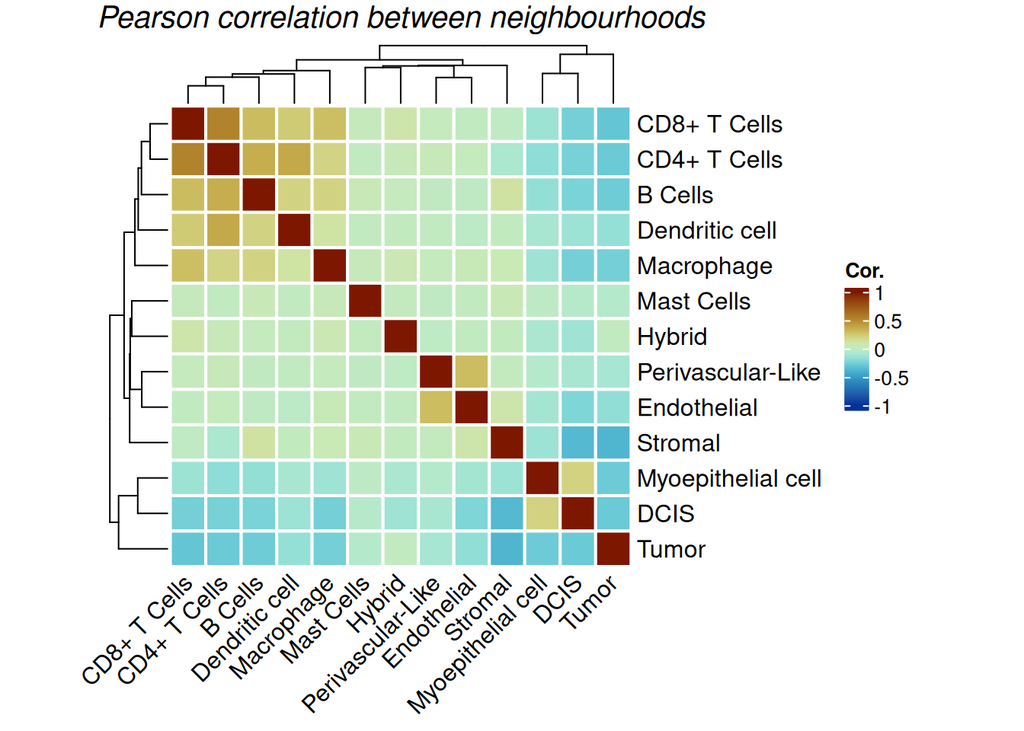

```r
# correlate neighborhood profiles between cell types to find co-localized pairs
hoodscanR::plotColocal(
  spe,
  pm_cols = colnames(hoods),
  hm_width = 8,
  hm_height = 8
)
```

Similar to what we saw when we made the heatmap of neighborhood profiles, we see that immune cells, specifically T cell types and B cells, have high correlation values and tend to co-localize together. In contrast, we see that the same immune cell types have low correlation with tumor cells, suggesting that they are less likely to be found together.

What other cell types co-localize with each other?

## Domain detection

The neighborhood profiles can also be used to partition the tissue into domains, or groups of cells with similar neighborhood profiles. `clustByHood()` does this by running k-means clustering on the per-cell neighborhood profiles, so cells are grouped by the company they keep rather than by their own expression.

This is conceptually related to domain-detection tools like `Banksy`, but the emphasis is different. With `Banksy` we cluster cells based on the gene expression of each cell and the cells around it. Here we are clustering cells by their neighborhood composition and do not (directly) consider gene expression. (Gene expression was used to assign cell types, so it does still affect the results!)

As with `k` in the nearest-neighbor step, the number of clusters `k` here is a choice we have to make, and it strongly shapes the result. To choose `k`, we will cluster the neighborhood profiles using a range of `k` values and create an elbow plot.

For each value of `k`, k-means assigns every cell to a domain, and we record the total within-cluster sum of squares (WCSS). The WCSS is the summed squared distance from each cell to the center of the domain it was assigned to, so a smaller value means cells sit closer to their domain’s center.

WCSS always decreases as `k` increases, because more domains means every cell has a closer center to belong to. A large drop tells us the new domain pulled apart two groups that really were different, while a small drop tells us it just split a group that was already fairly uniform. Therefore, we are looking for the point where the curve stops dropping steeply. That bend in the curve, the “elbow”, is the largest `k` that still buys us a meaningful improvement.

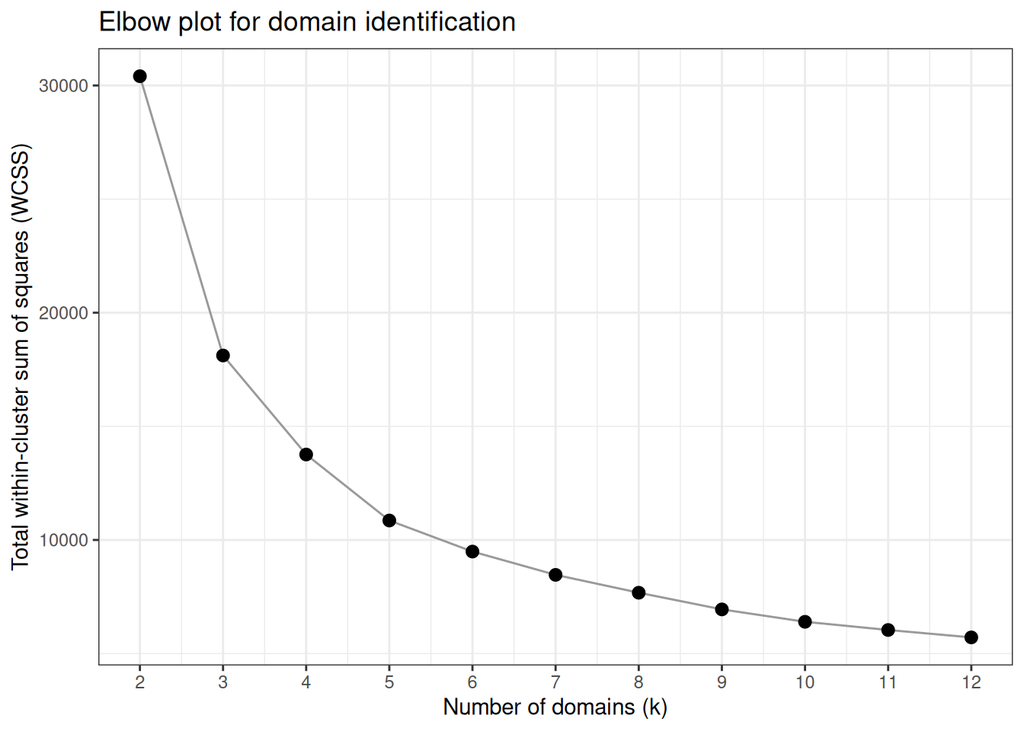

```r
# candidate numbers of domains to try
k_range <- 2:12

# construct a dataframe with value of k and within-cluster sum of squares
elbow_df <- tibble::tibble(k = k_range) |>
  dplyr::mutate(
    # fit k-means on the neighborhood probability matrix for each k...
    fit = purrr::map(k, \(x) {
      kmeans(hoods, centers = x, nstart = 25, iter.max = 50)
    }),
    # and pull out the total within-cluster sum of squares
    wcss = purrr::map_dbl(fit, "tot.withinss")
  )

# make the elbow plot
ggplot(elbow_df, aes(x = k, y = wcss)) +
  geom_line(colour = "grey60") +
  geom_point(size = 2.5) +
  scale_x_continuous(breaks = k_range) +
  labs(
    title = "Elbow plot for domain identification",
    x = "Number of domains (k)",
    y = "Total within-cluster sum of squares (WCSS)"
  )
```

From this plot we see that k=6 is a reasonable choice.

Keep in mind that picking the elbow is a judgment call rather than a calculation, and different people could reasonably read 5 or 7 off the same plot. What matters more is whether the domains you end up with are interpretable, which is exactly what we will check in the plots that follow. If several domains turn out to have nearly identical neighborhood profiles, that is a sign that `k` was too high. If a single domain is an obvious mix of two very different profiles, `k` is too low.

```r
# cluster cells into spatial domains based on their neighborhood profiles
spe <- hoodscanR::clustByHood(
  spe,
  pm_cols = colnames(hoods),
  k = 6 # number of domains, chosen from the elbow plot above
)
```

First, we will look at how many cells fall into each domain.

```r
table(spe$clusters)
```

```
    1     2     3     4     5     6
17735 16464 36514 27617 16699 20915
```

We can look at which cell types comprise each domain by plotting the distribution of neighborhood probabilities faceted by domain.

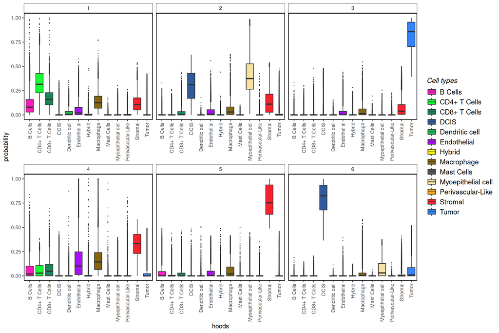

```r
# for each domain, show the distribution of neighborhood probabilities per cell type
hoodscanR::plotProbDist(
  spe,
  pm_cols = colnames(hoods),
  by_cluster = TRUE,
  plot_all = TRUE,
  fill = hoods,
  show_clusters = seq(6), # show 6 domains
  outlier.size = 0.1 # shrink the boxplot outlier points
) +
  # arrange the domains in 3 columns
  facet_wrap(vars(clusters), ncol = 3, scales = "free_x") +
  # and remove the strip background
  theme(strip.background = element_rect(fill = "transparent")) +
  # add some colors to cell types
  scale_fill_manual(values = cell_type_palette) +
  # change the default legend title
  labs(fill = "Cell types")
```

This plot is helpful in showing us which cell types contribute to which domain, and ultimately which cell types tend to be found in the same neighborhood profile. Specifically, we see that domain 3 is dominated by tumor cells, while domain 2 is a mix of DCIS and Myoepithelial cells.

What other patterns do you see?

Now we can map the domains back onto the tissue.

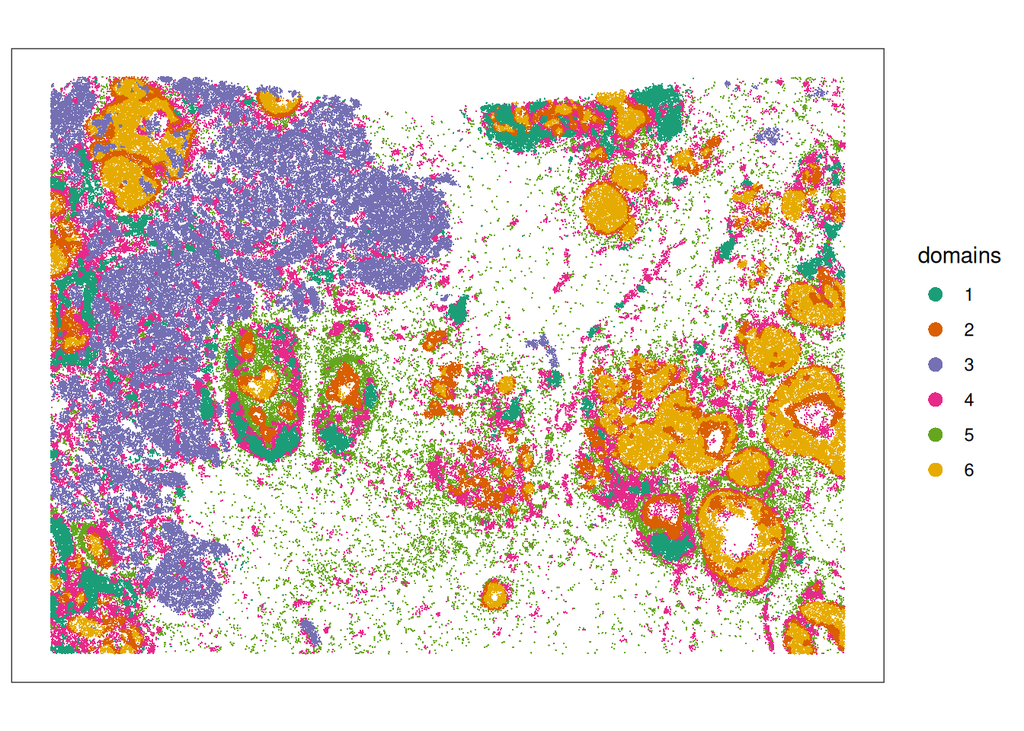

```r
# create a color palette to use for domain plots
domain_colors <- setNames(
  palette.colors(n = 6, palette = "Dark2"),
  1:6
)

# plot the domains across the tissue
ggspavis::plotCoords(spe, annotate = "clusters", point_size = 0.1) +
  scale_color_manual(values = domain_colors) +
  guides(
    color = ggplot2::guide_legend(
      override.aes = list(size = 3), # enlarge the legend keys so colors are readable
      title = "domains"
    )
  )
```

The overall complexity of cell types present within a domain should also be reflected in the perplexity measure we looked at earlier. We can plot the perplexity for all cells in each domain and see if that is true. Here we expect domains dominated by a single cell type to have a low perplexity while domains with a mix of cell types should have a high perplexity.

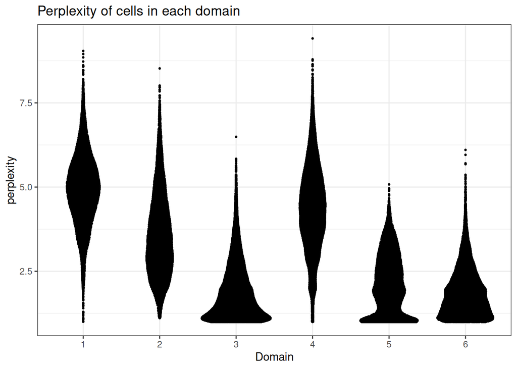

```r
# pull the colData into a data frame for plotting with ggplot2
coldata_df <- colData(spe) |>
  as.data.frame()

# using perplexity to measure the complexity of each domain
ggplot(coldata_df, aes(y = perplexity, x = clusters)) +
  ggforce::geom_sina(size = 0.5) +
  labs(
    x = "Domain",
    title = "Perplexity of cells in each domain"
  )
```

Here we see that the domains with a higher diversity of cell types (e.g., domains 1, 2, and 4) have a higher perplexity.

Finally, we will return to the heatmap we made earlier showing the neighborhood profile for the top 500 cells. We will enhance our plot by adding in the domains for each cell as a column-level annotation. We should see that cells with similar neighborhood profiles are assigned to the same domain.

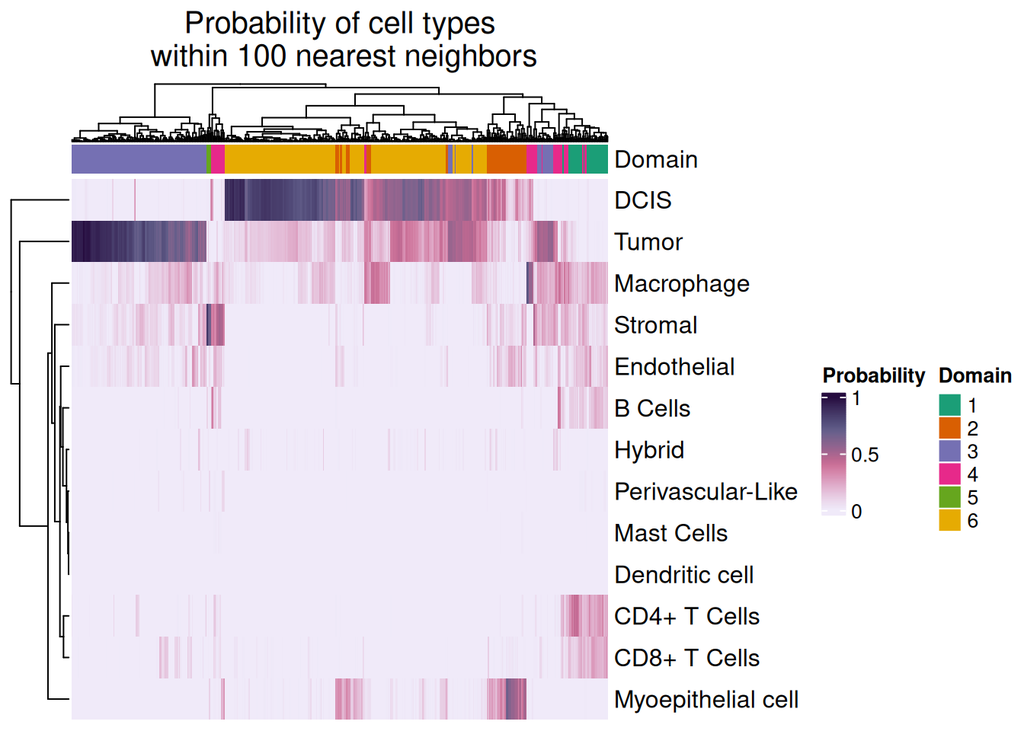

```r
# specify annotations to use for columns
domain_annotations <- ComplexHeatmap::columnAnnotation(
  "Domain" = spe$clusters[1:500],
  col = list("Domain" = domain_colors)
)

ComplexHeatmap::Heatmap(
  t(hoods[1:500, ]), # transpose so cells are columns
  col = scico::scico(200, palette = "acton", direction = -1),
  name = "Probability",
  column_title = "Probability of cell types\n within 100 nearest neighbors",
  column_title_gp = grid::gpar(fontsize = 15),
  column_dend_height = grid::unit(1, "cm"),
  row_dend_width = grid::unit(1, "cm"),
  top_annotation = domain_annotations,
  cluster_rows = TRUE, # group cells with similar profiles together
  cluster_columns = TRUE, # group cell types that co-occur together
  show_column_names = FALSE # hide per-cell labels; there are too many to read
)
```

Here we can see that domain 3 (on the left side of the plot) is composed of cells that all have mostly tumor cells in their local neighborhood. In contrast, cells that belong to domain 1 have varying types of immune cells in their local neighborhood.

## Export

Lastly, we’ll save our results by saving the modified SPE objects with the results from `hoodscanR`.

```r
readr::write_rds(spe, hoodscanr_results_file)
```